# Gapminder - loading data and viewing the structure

# The Gapminder Data

First we will load the gapminder library and the data.frame it contains.

Then you can find information about the gapminder dataset by viewing the documentation.

```r
library(gapminder)
data("gapminder")
help("gapminder")
```

Format

You may also explore the dataset to find out more about its structure using the following commands

```r
str(gapminder) # structure of the data.frame
```

```
Classes ‘tbl_df’, ‘tbl’ and 'data.frame':   1704 obs. of  6 variables:
 $ country  : Factor w/ 142 levels "Afghanistan",..: 1 1 1 1 1 1 1 1 1 1 ...
 $ continent: Factor w/ 5 levels "Africa","Americas",..: 3 3 3 3 3 3 3 3 3 3 ...
 $ year     : int  1952 1957 1962 1967 1972 1977 1982 1987 1992 1997 ...
 $ lifeExp  : num  28.8 30.3 32 34 36.1 ...
 $ pop      : int  8425333 9240934 10267083 11537966 13079460 14880372 12881816 13867957 16317921 22227415 ...
 $ gdpPercap: num  779 821 853 836 740 ...
```

```r
glimpse(gapminder) # this is only available from the dplyr package
```

```
Error in glimpse(gapminder) : could not find function "glimpse"
```

You can also view the content in various ways

```r
head(gapminder) # shows the first 6 rows of the data.frame
tail(gapminder) # shows the last 6 rows of the data.frame
```

[output not shown]

We can also display some summary information about the data.frame using the summary and table commands.

```r
summary(gapminder)
table(gapminder$continent) # note the $ sign to refer to a single variable in the data.frame
```

[output not shown]

# Basic graphical data exploration with graphs

## Histogram

A histogram shows the distribution of a single variable, usually across a horizontal axis. Observations are grouped into *bins* in order to show the distribution.

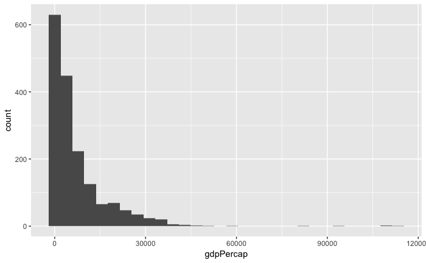

```r
ggplot(gapminder,
       aes(gdpPercap)) +
  geom_histogram()
```

## Box Plot

A box plot is useful for summarizing the distribution of a continuous variable in comparison to a categorical variable. It also dispays key values such as median, interquartile range, and outliers.

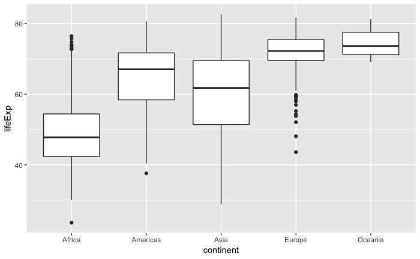

```r
ggplot(gapminder,
       aes(x = continent, y = lifeExp)) +
  geom_boxplot()
```

## Scatter Plot

Let’s create a scatter plot that shows lifeExp v. pop

Scatter plots work best for continuous numerical variables.

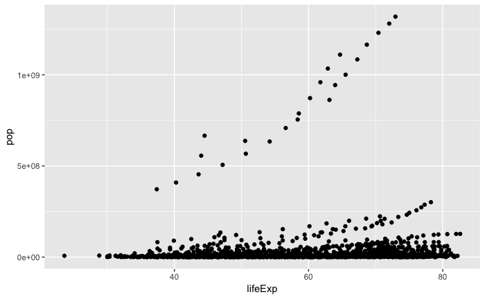

```r
ggplot(gapminder,
       aes(x = lifeExp, y = pop)) +
  geom_point()
```